# MH3511 Lab 8 Notes

Caleb Tay (caleb.tay@ntu.edu.sg)

27 Mar 2026

# Exercise 8.1

```r
a.data <- c(102, 86, 98, 109, 92)
b.data <- c(81, 165, 97, 134, 92, 87, 114)
```

Assuming normality with unequal variances, we need to consider the variance of each separately and weigh them.

Our alternative hypothesis is that “the average running time of films produced by Company B exceeds the average running time of films produced by Company A”. We want to find whether the data shows statistical evidence for this claim.

Translating that into symbols, we have $H_0: \mu_B \leq \mu_A$ and $H_1: \mu_B > \mu_A$, where $\mu_A$ and $\mu_B$ represent the average running time of films by company A and B respectively.

Rewriting it slightly, we have $H_0: \mu_B - \mu_A \leq 0$ and $H_1: \mu_B - \mu_A > 0$.

Now, we need a distribution to compare to based on our data. We will consider the two sample means $\bar{X}_A$ and $\bar{X}_B$. We have $\bar{X}_A \sim N(\mu_A, \sigma^2_A / n_A)$ and likewise $\bar{X}_B \sim N(\mu_B, \sigma^2_B / n_B)$.

Then consider the difference $(\bar{X}_B - \bar{X}_A) \sim N(\mu_B - \mu_A, \sigma^2_A / n_A + \sigma^2_B / n_B)$, which we can derive through properties of the normal distribution.

Under the null hypothesis, we have $\mu_B - \mu_A = 0$ and so $(\bar{X}_B - \bar{X}_A) \sim N(0, \sigma^2_A / n_A + \sigma^2_B / n_B)$. Normalising to have variance 1, we then have the usual test statistic:

$$\frac{\bar{X}_B - \bar{X}_A}
{\sqrt{\sigma^2_A / n_A + \sigma^2_B / n_B}}
\sim N(0, 1)$$

The number of degrees of freedom $v$ is kind of scuffed in the event of unequal variances. I don’t really know how it comes about, but it is reproduced here:

$$v =
\frac{\left(\frac{s_A^2}{n_A} + \frac{s_B^2}{n_B}\right)^2}
{\frac{1}{n_A - 1} \left(\frac{s_A^2}{n_A}\right)^2 +
\frac{1}{n_B - 1} \left(\frac{s_B^2}{n_B}\right)^2}$$

Now, in R:

```r
xbar.a <- mean(a.data)
xbar.b <- mean(b.data)
s.a <- sd(a.data)
s.b <- sd(b.data)
n.a <- length(a.data)
n.b <- length(b.data)

tstat <- (xbar.b - xbar.a) / sqrt(s.a^2 / n.a + s.b^2 / n.b)
tstat
```

```
## [1] 1.041941
```

```r
v <- ( (s.a^2 / n.a + s.b^2 / n.b)^2 ) / ( (s.a^2 / n.a)^2 / (n.a - 1) + (s.b^2 / n.b)^2 / (n.b - 1) )
v
```

```
## [1] 7.375586
```

```r
1 - pt(tstat, v)
```

```
## [1] 0.1651919
```

Note that depending on how we phrase the hypothesis, we could have considered either $H_1: \mu_B - \mu_A > 0$, or equivalently $H_1: \mu_A - \mu_B < 0$. These signify the same test, but will result in different test statistics (one positive, one negative).

Using $H_1: \mu_B - \mu_A > 0$ (as we did above), **large positive values of the test statistic act as evidence against the null hypothesis**. On the other hand, using $H_1: \mu_A - \mu_B < 0$ will mean that **large negative values of the test statistic act as evidence against the null hypothesis**.

You can see the difference if we use `t.test()` with reordered inputs. Essentially, it always takes the first argument minus second argument.

```r
t.test(a.data, b.data, alternative="less", var.equal=F) # a < b
```

```
##
##  Welch Two Sample t-test
##
## data:  a.data and b.data
## t = -1.0419, df = 7.3756, p-value = 0.1652
## alternative hypothesis: true difference in means is less than 0
## 95 percent confidence interval:
##      -Inf 10.13647
## sample estimates:
## mean of x mean of y
##      97.4     110.0
```

```r
t.test(b.data, a.data, alternative="greater", var.equal=F) # b > a
```

```
##
##  Welch Two Sample t-test
##
## data:  b.data and a.data
## t = 1.0419, df = 7.3756, p-value = 0.1652
## alternative hypothesis: true difference in means is greater than 0
## 95 percent confidence interval:
##  -10.13647       Inf
## sample estimates:
## mean of x mean of y
##     110.0      97.4
```

From this, we can see that there is no significant statistical evidence against the null hypothesis at a 10% significance level.

# Exercise 8.2

```r
faculty <- read.table("Lab08faculty.txt")
str(faculty)
```

```
## 'data.frame':    514 obs. of  10 variables:
##  $ salary   : num  38362 68906 55979 61008 42977 ...
##  $ exprior  : int  0 2 0 0 5 4 1 0 0 0 ...
##  $ yearsbg  : int  14 29 14 3 7 13 8 0 25 2 ...
##  $ yearsrank: int  2 20 3 3 1 5 4 0 5 1 ...
##  $ market   : num  0.72 1 1.04 1.24 0.99 ...
##  $ termdeg  : int  1 1 1 1 1 1 1 1 1 1 ...
##  $ admin    : int  0 0 0 0 0 0 0 0 0 0 ...
##  $ yearsdg  : int  14 31 14 2 12 17 9 0 23 1 ...
##  $ rank     : chr  "Associate" "Full" "Full" "Assistant" ...
##  $ male     : chr  "Women" "Men" "Men" "Men" ...
```

```r
# ?aggregate
aggregate(faculty$salary, list(faculty$male), FUN=length)
```

```
##   Group.1   x
## 1     Men 386
## 2   Women 128
```

```r
aggregate(salary ~ male, data=faculty, FUN=length)
```

```
##    male salary
## 1   Men    386
## 2 Women    128
```

```r
library(dplyr)
faculty %>% group_by(male) %>% summarise(n())
```

```
## # A tibble: 2 × 2
##   male  `n()`
##   <chr> <int>
## 1 Men     386
## 2 Women   128
```

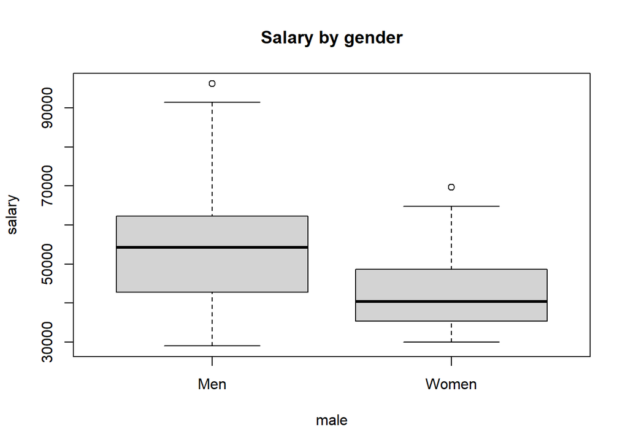

```r
boxplot(salary ~ male, data=faculty, main="Salary by gender")
```

Before testing for differences in the mean of each population, we have to determine if it is reasonable that both populations have the same variance or not. Simply looking at the values, we can see a nearly two times difference in the variances.

```r
salary.m <- faculty[faculty$male == "Men", "salary"]
salary.f <- faculty[faculty$male == "Women", "salary"]

var(salary.m)
```

```
## [1] 158343927
```

```r
var(salary.f)
```

```
## [1] 83935090
```

To test this statistically, the idea is simple: we simply take the ratio between these two variances. Our test is then simple: $H_0:$ the variances are equal, i.e. their ratio is 1, and $H_1:$ the variances are not equal, i.e. their ratio is not 1.

Some brief notes on how this statistic is derived (outside of the course contents): we have our sample variances $s^2_A$ and $s^2_B$, which have $\chi^2_{n_A-1}$ and $\chi^2_{n_B-1}$ distributions respectively. The ratio of two $\chi^2$ variables is F-distributed, with parameters $n_A-1$ and $n_B-1$, the degrees of freedom of each $\chi^2$ variable.

Our test statistic, the ratio of the variances is 1.886505. Values far away from 1 are evidence against $H_0$. Since 1.886505 > 1, we consider the right tail probability and multiply by two to get the corresponding p-value.

```r
# Manual calculation
fstat <- var(salary.m) / var(salary.f)
fstat
```

```
## [1] 1.886505
```

```r
n.salary.m <- length(salary.m)
n.salary.f <- length(salary.f)
(1 - pf(fstat, n.salary.m - 1, n.salary.f - 1))*2
```

```
## [1] 3.903557e-05
```

```r
# Using var.test()
var.test(salary.m, salary.f)
```

```
##
##  F test to compare two variances
##
## data:  salary.m and salary.f
## F = 1.8865, num df = 385, denom df = 127, p-value = 3.904e-05
## alternative hypothesis: true ratio of variances is not equal to 1
## 95 percent confidence interval:
##  1.404604 2.481945
## sample estimates:
## ratio of variances
##           1.886505
```

The test indicates there is significant statistical evidence that the variances are not equal. Thus, to compare the sample means, we assume the variances are not equal. The process is similar to Exercise 8.1 above.

```r
t.test(salary.m, salary.f, alternative="greater", var.equal=F)
```

```
##
##  Welch Two Sample t-test
##
## data:  salary.m and salary.f
## t = 10.25, df = 297.23, p-value < 2.2e-16
## alternative hypothesis: true difference in means is greater than 0
## 95 percent confidence interval:
##  8879.088      Inf
## sample estimates:
## mean of x mean of y
##  53499.24  42916.60
```

We repeat the process for the data for assistant professors.

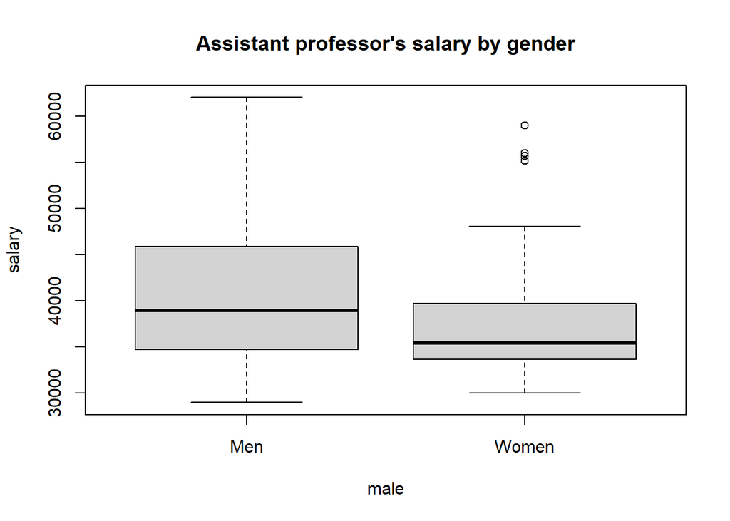

```r
salary.m.asst <- subset(faculty, male == "Men" & rank == "Assistant")$salary
salary.f.asst <- subset(faculty, male == "Women" & rank == "Assistant")$salary

boxplot(salary ~ male, subset(faculty, rank == "Assistant"),
        main="Assistant professor's salary by gender")
```

```r
var.test(salary.m.asst, salary.f.asst)
```

```
##
##  F test to compare two variances
##
## data:  salary.m.asst and salary.f.asst
## F = 1.911, num df = 82, denom df = 59, p-value = 0.009523
## alternative hypothesis: true ratio of variances is not equal to 1
## 95 percent confidence interval:
##  1.174675 3.050915
## sample estimates:
## ratio of variances
##            1.91096
```

```r
var.test(salary.f.asst, salary.m.asst)
```

```
##
##  F test to compare two variances
##
## data:  salary.f.asst and salary.m.asst
## F = 0.5233, num df = 59, denom df = 82, p-value = 0.009523
## alternative hypothesis: true ratio of variances is not equal to 1
## 95 percent confidence interval:
##  0.3277706 0.8512992
## sample estimates:
## ratio of variances
##          0.5232972
```

```r
t.test(salary.m.asst, salary.f.asst, alternative="greater", var.equal=F)
```

```
##
##  Welch Two Sample t-test
##
## data:  salary.m.asst and salary.f.asst
## t = 2.9471, df = 141, p-value = 0.001878
## alternative hypothesis: true difference in means is greater than 0
## 95 percent confidence interval:
##  1715.509      Inf
## sample estimates:
## mean of x mean of y
##  41508.57  37593.45
```

# Exercise 8.3

Here, we have **paired data** and are interested in testing the effect of something - in the context of this question, the effect of a fertiliser on crop yields.

Since the samples are paired, it is not logical to test the sample means separately - since we are interested in the **effect** of the new testing condition. If we took the sample means separately and compared them, then we are saying that the data were all independent - which is not the case here.

So we can compare the paired data directly, or consider their pairwise differences as a single sample.

```r
fert.new <- c(2250, 2410, 2260, 2200, 2360, 2320, 2240, 2300, 2090)
fert.old <- c(1920, 2020, 2060, 1960, 1960, 2140, 1980, 1940, 1790)

t.test(fert.new, fert.old, paired=T, mu=250, alternative="greater")
```

```
##
##  Paired t-test
##
## data:  fert.new and fert.old
## t = 1.6948, df = 8, p-value = 0.06428
## alternative hypothesis: true mean difference is greater than 250
## 95 percent confidence interval:
##  245.571     Inf
## sample estimates:
## mean difference
##        295.5556
```

```r
# fert.new - fert.old > 250

fert.diff <- fert.new - fert.old
t.test(fert.diff, mu=250, alternative="greater")
```

```
##
##  One Sample t-test
##
## data:  fert.diff
## t = 1.6948, df = 8, p-value = 0.06428
## alternative hypothesis: true mean is greater than 250
## 95 percent confidence interval:
##  245.571     Inf
## sample estimates:
## mean of x
##  295.5556
```

# Exercise 8.4

Here is one way to store the data that I would not quite agree with. It is much shorter (9 rows), but suggests some relation between the rows (e.g. that 1 row represents a single patient). It can, however, be reshaped/pivoted into a more ‘correct’ structure (though it is outside the scope of this course).

```r
bad_pain <- data.frame(A = c(4, 5, 4, 3, 2, 4, 3, 4, 4),
                       B = c(6, 8, 4, 5, 4, 6, 5, 8, 6),
                       C = c(6, 7, 6, 6, 7, 5, 6, 5, 5))
# tidyr::pivot_longer(bad_pain, c("A", "B", "C"), names_to="drug")
```

```r
pain <- data.frame(response = c(c(4, 5, 4, 3, 2, 4, 3, 4, 4),
                                c(6, 8, 4, 5, 4, 6, 5, 8, 6),
                                c(6, 7, 6, 6, 7, 5, 6, 5, 5)),
                   drug = factor(rep(c("A", "B", "C"), c(9, 9, 9))))
head(pain)
```

```
##   response drug
## 1        4    A
## 2        5    A
## 3        4    A
## 4        3    A
## 5        2    A
## 6        4    A
```

To counter the tutorial’s wording: boxplots don’t show anything about the mean, only the median!

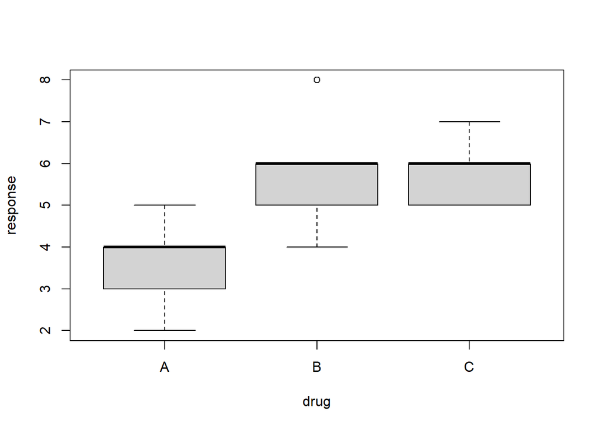

```r
boxplot(response ~ drug, data=pain)
```

```r
aggregate(pain$response, list(pain$drug), FUN=summary)
```

```
##   Group.1   x.Min. x.1st Qu. x.Median   x.Mean x.3rd Qu.   x.Max.
## 1       A 2.000000  3.000000 4.000000 3.666667  4.000000 5.000000
## 2       B 4.000000  5.000000 6.000000 5.777778  6.000000 8.000000
## 3       C 5.000000  5.000000 6.000000 5.888889  6.000000 7.000000
```

```r
aggregate(pain$response, list(pain$drug), FUN=length)
```

```
##   Group.1 x
## 1       A 9
## 2       B 9
## 3       C 9
```

```r
aggregate(pain$response, list(pain$drug), FUN=var)
```

```
##   Group.1         x
## 1       A 0.7500000
## 2       B 2.1944444
## 3       C 0.6111111
```

```r
aggregate(response~drug, FUN=length, data=pain)
```

```
##   drug response
## 1    A        9
## 2    B        9
## 3    C        9
```

```r
aggregate(response~drug, FUN=var, data=pain)
```

```
##   drug  response
## 1    A 0.7500000
## 2    B 2.1944444
## 3    C 0.6111111
```

```r
library(dplyr)
pain %>% group_by(drug) %>% summarise(n(), var(response))
```

```
## # A tibble: 3 × 3
##   drug  `n()` `var(response)`
##   <fct> <int>           <dbl>
## 1 A         9           0.75
## 2 B         9           2.19
## 3 C         9           0.611
```

What we are interested in testing is whether there is a difference in the response among the drugs. To do so, it is possible that we could perform a pairwise t-test on every pair here, i.e. A-B, B-C, and A-C. However, the issue is that these pairwise t-tests have a type-I error, which accumulates the more tests we do.

If we were only interested whether there is a difference between some of the populations, we can perform a single ANalysis Of VAriances (ANOVA) test, which keeps a constant type-I error rate.

Our null hypothesis is $H_0: \mu_A = \mu_B = \mu_C$ and alternative hypothesis $H_1: \mu_i \neq \mu_j$ for some $i \neq j, i, j \in \{A, B,C \}$.

There are actually some important assumptions that must be true for an ANOVA test to be valid, the most important of which is that the observations are independent and identically distributed. You can read more about it [here](https://cran.r-project.org/web/packages/afex/vignettes/assumptions_of_ANOVAs.html).

The statistic that we use is going to be a ratio of variances. We have three sum-of-squares quantities, which measure some part of the dataset’s variation:

$$SSB = \sum_{i=1}^k \sum_{j=1}^{n_i} (\bar{X}_i - \bar{X})^2 =
\sum_{i=1}^k n_i (\bar{X}_i - \bar{X})^2
\\
SSW = \sum_{i=1}^k \sum_{j=1}^{n_i} (X_{ij} - \bar{X}_i)^2
\\
SST = \sum_{i=1}^k \sum_{j=1}^{n_i} (X_{ij} - \bar{X})^2 = (n-1)s^2$$

which are related by $SST = SSB + SSW$. What we want is SSB and SSW.

```r
sst <- sum((pain$response - mean(pain$response))^2)

drug.means <- aggregate(pain$response, list(pain$drug), mean)
drug.n <- aggregate(pain$response, list(pain$drug), length)
ssb <- sum(drug.n['x'] * (drug.means['x'] - mean(pain$response))^2)

ssw <- sst - ssb

ssb; ssw; sst
```

```
## [1] 28.22222
```

```
## [1] 28.44444
```

```
## [1] 56.66667
```

The values we use in our test statistic are $S_w^2$ and $S_b^2$, which we can get from $SSW$ and $SSB$:

$$S_w^2 = \frac{1}{n-k} \sum_{i=1}^k \sum_{j=1}^{n_i} (X_{ij} -
\bar{X}_i)^2
= \frac{1}{n-k} \sum_{i=1}(n_i - 1) S_i^2
= \frac{1}{n-k} SSW
\\
S_b^2 = \frac{1}{k-1} \sum_{i=1}^k \sum_{j=1}^{n_i} (\bar{X}_i -
\bar{X})^2
= \frac{1}{k-1} \sum_{i=1}^k n_i (\bar{X}_i - \bar{X})^2 = \frac{1}{k-1}
SSB$$

Here, I take $T = S_w^2 / S_b^2$. Under the null hypothesis, if $\mu_i = \mu_j$ for all $i, j$, then we expect $S_b^2$ to be small. Thus, large $S_b^2$ act as evidence against the null hypothesis. Since $S_b^2$ is in the denominator, large values of $S_b^2$ lead to small values of $T$, which is evidence against the null hypothesis.

```r
n <- length(pain$response)
k <- 3 # 3 drug types, A, B, C.
fstat <- (ssw/(n-k)) / (ssb/(k-1)); fstat
```

```
## [1] 0.0839895
```

```r
pf(fstat, n-k, k-1)
```

```
## [1] 0.0002558807
```

This whole process is encapsulated in `aov()`. You can see where the values calculated manually match up.

```r
paste(k-1, ssb, ssb/(k-1)); paste(n-k, ssw, ssw/(n-k))
```

```
## [1] "2 28.2222222222222 14.1111111111111"
```

```
## [1] "24 28.4444444444444 1.18518518518518"
```

```r
fstat^-1
```

```
## [1] 11.90625
```

```r
summary(aov(response ~ drug, data=pain))
```

```
##             Df Sum Sq Mean Sq F value   Pr(>F)
## drug         2  28.22  14.111   11.91 0.000256 ***
## Residuals   24  28.44   1.185
## ---
## Signif. codes:  0 '***' 0.001 '**' 0.01 '*' 0.05 '.' 0.1 ' ' 1
```

Small values signify evidence against the null hypothesis. We get a p-value of 0.000256, which suggests we reject the null hypothesis that there is no difference in the effect of the drugs.

Then, we can carry on to do a post-hoc analysis (follow-up analysis) with pairwise t-tests. Here, among all three groups, we treat them as having equal standard deviations, which is appropriate **given the assumptions we already used when conducting the ANOVA test**.

```r
pairwise.t.test(pain$response, pain$drug, p.adjust.method="none", pool.sd=T)
```

```
##
##  Pairwise comparisons using t tests with pooled SD
##
## data:  pain$response and pain$drug
##
##   A       B
## B 0.00040 -
## C 0.00023 0.83042
##
## P value adjustment method: none
```

Just to relate it to our usual t-tests: in our t-test function, we are unable to specify a fixed variance to use. If we say `var.equal=T`, we are only assuming the two sets of data have equal variances, which goes **against our assumptions we used in conducting the ANOVA test**.

```r
pairwise.t.test(pain$response, pain$drug, p.adjust.method="none", pool.sd=F)$p.val
```

```
##              A         B
## B 2.751366e-03        NA
## C 3.325942e-05 0.8455524
```

```r
response.a <- subset(pain, drug == "A")$response
response.b <- subset(pain, drug == "B")$response
response.c <- subset(pain, drug == "C")$response
t.test(response.a, response.b, var.equal=F)$p.val
```

```
## [1] 0.002751366
```

```r
t.test(response.a, response.c, var.equal=F)$p.val
```

```
## [1] 3.325942e-05
```

```r
t.test(response.b, response.c, var.equal=F)$p.val
```

```
## [1] 0.8455524
```